# Act Report

### By Yasmine Hussein

```
     November 2020
```

“WeRateDogs is a Twitter account that rates people's dogs with a humorous comment about the dog. It was started in 2015 by college student Matt Nelson and has received international media coverage both for its popularity and for the attention drawn to social media copyright law when it was suspended by Twitter.”, from Wikipedia. As of December 2017, the Twitter account has nearly 4.56 million followers.  
The data, which was made available to me by Udacity as part of my Data Analyst Nanodegree program only  
included tweets up to August 1st, 2017 and were then filtered to remove retweets, tweets with dog breed  
missing and tweets where there was no image.

From the WeRateDogs Twitter account we can obtain quickly some initial information to start with:

We can answer the following questions:

- Which breeds are most tweeted about?
- Which breeds obtain the highest ratings?
- Which breeds receive most likes?

```python
# Import visualization libraries
import pandas as pd
import matplotlib.pyplot as plt
# 'Magic word' so that your visualizations are plotted
%matplotlib inline
# Read the data
df_clean = pd.read_csv('twitter_archive_master.csv')
# Quick analysis of some of the numbers
df_clean.describe()
```

|  | tweet_id | rating_numerator | rating_denominator | favorites | retweet_count | img_num | p1_conf | p2_conf | p3_conf |
| --- | --- | --- | --- | --- | --- | --- | --- | --- | --- |
| count | 1.964000e+03 | 1964.000000 | 1964.000000 | 1964.000000 | 1964.000000 | 1964.000000 | 1964.000000 | 1.964000e+03 | 1.964000e+03 |
| mean | 7.358154e+17 | 12.223014 | 10.479124 | 8140.168534 | 2400.277495 | 1.202138 | 0.593928 | 1.346393e-01 | 6.028936e-02 |
| std | 6.744191e+16 | 41.708155 | 6.865424 | 11973.685598 | 4289.830947 | 0.559615 | 0.272134 | 1.009430e-01 | 5.096697e-02 |
| min | 6.660209e+17 | 0.000000 | 2.000000 | 69.000000 | 11.000000 | 1.000000 | 0.044333 | 1.011300e-08 | 1.740170e-10 |
| 25% | 6.758399e+17 | 10.000000 | 10.000000 | 1745.750000 | 534.750000 | 1.000000 | 0.362775 | 5.352722e-02 | 1.619708e-02 |
| 50% | 7.087246e+17 | 11.000000 | 10.000000 | 3673.500000 | 1161.000000 | 1.000000 | 0.587357 | 1.173995e-01 | 4.947920e-02 |
| 75% | 7.877408e+17 | 12.000000 | 10.000000 | 10159.000000 | 2742.000000 | 1.000000 | 0.847062 | 1.955617e-01 | 9.162278e-02 |
| max | 8.924206e+17 | 1776.000000 | 170.000000 | 152489.000000 | 75465.000000 | 4.000000 | 1.000000 | 4.880140e-01 | 2.734190e-01 |

```python
# Which breeds are most tweeted
df_clean.dog_type.value_counts()
```

```
None       1662
pupper      209
doggo        62
puppo        23
floofer       8
Name: dog_type, dtype: int64
```

#### so pupper is the most tweeted dog breed!

```python
##Which breeds obtain the highest ratings?
df_clean.loc[df_clean.rating_numerator.max()].dog_type
```

```
'pupper'
```

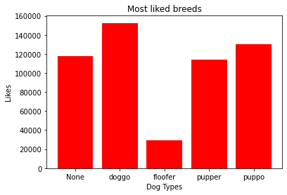

```python
# Plot a bar chart
plt.bar(df_clean.dog_type, df_clean.favorites, color= 'red')
plt.xlabel("Dog Types")
plt.ylabel("Likes")
plt.title("Most liked breeds")
```

#### from chart we can see the doggo breed type has the most likes!